# Homework week 10 day 1

```r
library(tidyverse)
library(modelr)
library(broom)
library(janitor)
library(ggfortify)
```

## 1. Load the data into a dataframe `project`

```r
project <- read_csv("data/project_management.csv")
```

## 2. Plot the data, taking estimated_length as the independent variable and actual_length as the dependent variable.

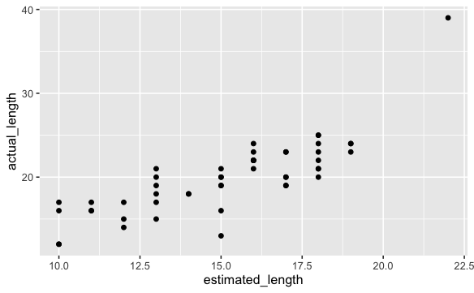

```r
project %>%
  ggplot(aes(x = estimated_length, y = actual_length)) +
  geom_point()
```

## 3. Calculate the correlation coefficient of estimated_length and actual_length and interpret the value you obtain.

Very strong correlation - between 0.8 and 0.99

```r
project %>%
  summarise(cor(estimated_length, actual_length))
```

| cor(estimated_length, actual_length) |
| --- |
| 0.8046597 |

## 4. Perform a simple linear regression using actual_length as the dependent variable, and estimated_length as the independent variable. Save the model object to a variable.

**always y ~ x**

```r
model <- lm(formula = actual_length ~ estimated_length, data = project)

model
```

```
Call:
lm(formula = actual_length ~ estimated_length, data = project)

Coefficients:
     (Intercept)  estimated_length
           1.416             1.223
```

## 5. Interpret the regression coefficient of estimated_length (i.e. slope, gradient) you obtain from the model. How do you interpret the r2 value reported by the model?

Ignoring the outlier at (39,22) it seems reasonable?

r2 0.64: some of variation explained by explanitory variable?

```r
glance_output <- clean_names(glance(model))
glance_output
```

| r_squared | adj_r_squared | sigma | statistic | p_value | df | log_lik | aic | bic | deviance | df_residual | nobs |
| --- | --- | --- | --- | --- | --- | --- | --- | --- | --- | --- | --- |
| 0.6474772 | 0.640133 | 2.606163 | 88.16142 | 1.911284e-12 | 1 | -117.8203 | 241.6407 | 247.3767 | 326.0201 | 48 | 50 |

```r
tidy_output <- clean_names(tidy(model))
tidy_output
```

| term | estimate | std_error | statistic | p_value |
| --- | --- | --- | --- | --- |
| (Intercept) | 1.416379 | 2.0069491 | 0.7057375 | 4.837627e-01 |
| estimated_length | 1.223489 | 0.1303049 | 9.3894314 | 1.911284e-12 |

```r
project <- project %>%
  add_predictions(model) %>%
  add_residuals(model)  %>%
  arrange(desc(actual_length))
project
```

| X1 | estimated_length | actual_length | pred | resid |
| --- | --- | --- | --- | --- |
| 5 | 22 | 39 | 28.33313 | 10.66686666 |
| 4 | 18 | 25 | 23.43918 | 1.56082196 |
| 38 | 18 | 25 | 23.43918 | 1.56082196 |
| 6 | 19 | 24 | 24.66267 | -0.66266687 |
| 7 | 18 | 24 | 23.43918 | 0.56082196 |
| 27 | 16 | 24 | 20.99220 | 3.00779961 |
| 32 | 19 | 24 | 24.66267 | -0.66266687 |
| 3 | 16 | 23 | 20.99220 | 2.00779961 |
| 9 | 18 | 23 | 23.43918 | -0.43917804 |
| 42 | 17 | 23 | 22.21569 | 0.78431078 |

[output cut: 40 more lines]

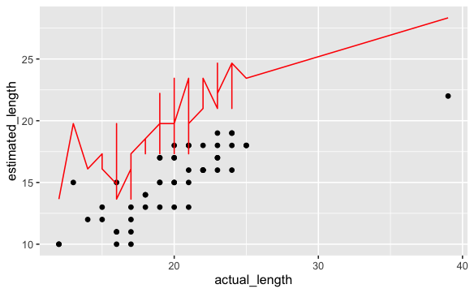

```r
project %>%
ggplot(aes(x = actual_length)) +
  geom_point(aes(y = estimated_length)) +
  geom_line(aes(y = pred), col = "red")
```

## 6. Is the relationship statistically significant? Remember, to assess this you need to check the p-value of the regression coefficient (or slope/gradient). But you should first check the regression diagnostic plots to see if the p-value will be reliable (don’t worry about any outlier points you see in the diagnostic plots, we’ll return to them in the extension).

p-value = 1.911284^12?

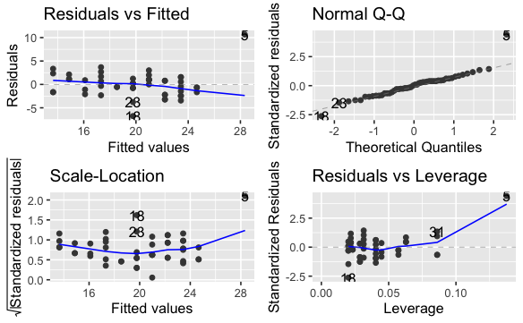

```r
autoplot(model)
```